# 6.6 Lab 2: Ridge Regression and the Lasso

We will use the **glmnet** package in order to perform ridge regression and the lasso. The main function in this package is **glmnet()**, which can be used to fit ridge regression models, lasso models, and more. This function has a slightly different syntax from other model-fitting functions that we have encountered thus far in this book. In particular, we must pass in an **x** matrix as well as a **y** vector, and we do not use the **y ~ x** syntax. We will now perform ridge regression and the lasso in order to predict **Salary** on the **Hitters** data. Before proceeding esnure that the missing values have been removed from the data, as described in Section 6.5.

```r
library(ISLR)
Hitters = na.omit(Hitters)
x = model.matrix(Salary ~ ., Hitters[,-1])
y = Hitters$Salary
```

# 6.6.1 Ridge Regression

The **glmnet()** function has an **alpha** argument that determines what type of model is fit. If **alpha = 0** then a ridge regression model is fit, and if **alpha = 1**, then a lasso model is fit. We first fit a ridge regression model.

```r
library(glmnet)
grid = 10^seq(10, -2, length = 100)
ridge.mod = glmnet(x, y, alpha = 0, lambda = grid)
```

By default the **glmnet()** function performs ridge regression for an automatically selected range of $\lambda$ values. However, here we have chosen to implement the function over a grid of values ranging from $\lambda = 10^{10}$ to $\lambda = 10^{-2}$, essentially covering the full range of scenarios from the null model containing only the intercept, to the least squares fit. As we will see, we can also compute model fits for a particular value of $\lambda$ that is not one of the original **grid** values. Note that by default, the **glmnet()** function standardizes the variables so that they are on the same scale. To turn off this default setting, use the argument **standardize = FALSE**.

Associated with each value of $\lambda$ is a vector of ridge regression coefficients, stored in a matrix that can be accessed by **coef()**. In this case, it is a 20x100 matrix, with 20 rows (one for each predictors, plus an intercept) and 100 columns (one for each value of $\lambda$).

```r
dim(coef(ridge.mod))
```

```
## [1]  20 100
```

We expect the coefficient estimates to be much smaller, in terms of $l_2$ norm, when a large value of $\lambda$ is used, as compared to when a small value of $\lambda$ is used. These are the coefficients when $\lambda = 11,498$, along with their $l_2$ norm:

```r
ridge.mod$lambda[50]
```

```
## [1] 11497.57
```

```r
coef(ridge.mod)[,50]
```

```
##   (Intercept)   (Intercept)          Hits         HmRun          Runs
## 420.533628801   0.000000000   0.142161648   0.535753108   0.237192308
##           RBI         Walks         Years        CAtBat         CHits
##   0.245400352   0.294764855   1.106768479   0.003145563   0.011707483
##        CHmRun         CRuns          CRBI        CWalks       LeagueN
##   0.087922960   0.023490502   0.024240472   0.025077345   0.031809908
##     DivisionW       PutOuts       Assists        Errors    NewLeagueN
##  -6.233613725   0.016680815   0.003066598  -0.011195017   0.272473462
```

```r
sqrt(sum(coef(ridge.mod)[-1,50]^2))
```

```
## [1] 6.377993
```

In contrast, here are the coefficients when $\lambda = 705$, along with their $l_2$ norm. Note the much larger $l_2$ norm of the coefficients with this smaller value of $\lambda$.

```r
ridge.mod$lambda[60]
```

```
## [1] 705.4802
```

```r
coef(ridge.mod)[,60]
```

```
##  (Intercept)  (Intercept)         Hits        HmRun         Runs
##  73.19638878   0.00000000   0.73352553   1.30217041   1.05007453
##          RBI        Walks        Years       CAtBat        CHits
##   0.93206155   1.39062240   2.52015165   0.01096233   0.04728773
##       CHmRun        CRuns         CRBI       CWalks      LeagueN
##   0.33786629   0.09449238   0.09826829   0.07092441  13.05069426
##    DivisionW      PutOuts      Assists       Errors   NewLeagueN
## -54.60596556   0.12107727   0.02494856  -0.55777612   8.59917937
```

```r
sqrt(sum(coef(ridge.mod)[-1,60]^2))
```

```
## [1] 56.91252
```

We can use the **predict()** function for a number of purposes. For instance, we can obtain the ridge regression coefficients for a new value of $\lambda$, say 50:

```r
predict(ridge.mod, s = 50, type = 'coefficients')[1:20,]
```

```
##   (Intercept)   (Intercept)          Hits         HmRun          Runs
##   23.18705218    0.00000000    1.41400571   -1.26017928    0.67493519
##           RBI         Walks         Years        CAtBat         CHits
##    0.48417073    2.52681622   -5.87879262    0.00398633    0.10433894
##        CHmRun         CRuns          CRBI        CWalks       LeagueN
##    0.61704523    0.21806578    0.22156158   -0.13369584   49.08322428
##     DivisionW       PutOuts       Assists        Errors    NewLeagueN
## -120.86206156    0.24422330    0.08591212   -3.57430320  -12.43855470
```

We now split the samples into a training set and a test set in order to estimate the test error of ridge regression and the lasso. There are two common ways to randomly split a data set. The first is to produce a random vector of **TRUE**, **FALSE** elements and select the observations corresponding to **TRUE** for the training data. The second is to randomly choose a subset of numbers between 1 and *n*; these can then be used as the indices for the training observations. The two approaches work equally well. We used the former method in Section 6.5.3. Here we demonstrate the latter approach.

We first set a random seed so that the results obtained will be reporudcible.

```r
set.seed(1)
train = sample(1:nrow(x), nrow(x)/2)
test = (-train)
y.test = y[test]
```

Next we fit a ridge regression model on the training set, and evaluate its MSE on the test set, using $\lambda = 4$. Note the use of the **predict()** function again. This time we get predictions for a test set, by replacing **type=“coefficients”** with the **newx** argument.

```r
ridge.mod = glmnet(x[train,], y[train], alpha = 0, lambda = grid, thresh = 1e-12)
ridge.pred = predict(ridge.mod, s = 4, newx = x[test,])
mean((ridge.pred - y.test)^2)
```

```
## [1] 107731.5
```

```r
mean((mean(y[train]) - y.test)^2)
```

```
## [1] 193253.1
```

We could also get the same result by fitting a ridge regression model with a *very* large value of $\lambda$. Note that **1e10** means $10^{10}$.

```r
ridge.pred = predict(ridge.mod, s = 1e10, newx = x[test,])
mean((ridge.pred - y.test)^2)
```

```
## [1] 193253.1
```

So fitting a ridge regression model with $\lambda = 4$ leads to a much lower test MSE than fitting a model with just an intercept. We now check whether there is any benefit to performing ridge regression with $\lambda = 4$ instead of just performing least squares regression. Recall that least squares is simply ridge regression with $\lambda = 0$.

```r
#ridge.pred = predict(ridge.mod, s = 0, newx = x[test,], exact = TRUE)
ridge.pred = predict(ridge.mod, s = 0, newx = x[test,])
mean((ridge.pred - y.test)^2)
```

```
## [1] 122927.1
```

```r
lm(y ~ x, subset = train)
```

```
##
## Call:
## lm(formula = y ~ x, subset = train)
##
## Coefficients:
##  (Intercept)  x(Intercept)         xHits        xHmRun         xRuns
##     191.2013            NA        1.2699       10.7712       -8.4450
##         xRBI        xWalks        xYears       xCAtBat        xCHits
##       1.4820        7.4691      -16.8688       -0.4000        0.8753
##      xCHmRun        xCRuns         xCRBI       xCWalks      xLeagueN
##      -0.9768        2.5616       -0.1611       -0.5112       71.8944
##   xDivisionW      xPutOuts      xAssists       xErrors   xNewLeagueN
##    -113.9401        0.2859        0.1601       -0.8704      -13.1337
```

```r
#predict(ridge.mod, s = 0, exact = TRUE, type = 'coefficients')[1:20,]
predict(ridge.mod, s = 0, type = 'coefficients')[1:20,]
```

```
##  (Intercept)  (Intercept)         Hits        HmRun         Runs
##  190.9617139    0.0000000    1.2793791   10.7956267   -8.4461360
##          RBI        Walks        Years       CAtBat        CHits
##    1.4634962    7.4756837  -16.9265952   -0.3966906    0.8624922
##       CHmRun        CRuns         CRBI       CWalks      LeagueN
##   -0.9897737    2.5623244   -0.1541285   -0.5138003   71.6645361
##    DivisionW      PutOuts      Assists       Errors   NewLeagueN
## -114.1440109    0.2860706    0.1592226   -0.8777368  -13.0433027
```

In general, if we want to fit a (unpenalized) least squares model, then we should use the **lm()** function, since that function provides more useful outputs, such as standard errors and p-values for the coefficients.

In general, instead of arbitrarily choosing $\lambda = 4$, it would be better to use cross-validation to choose the tuning parameter $\lambda$. We can do this using the built-in cross-validation function, **cv.glmnet()**. By default, the function performs ten-fold cross-validation, though this can be chagned using the argument **nfolds**. Note that we set a random seed first so our results will be reproducible, since the choice of the cross-validation folds is random.

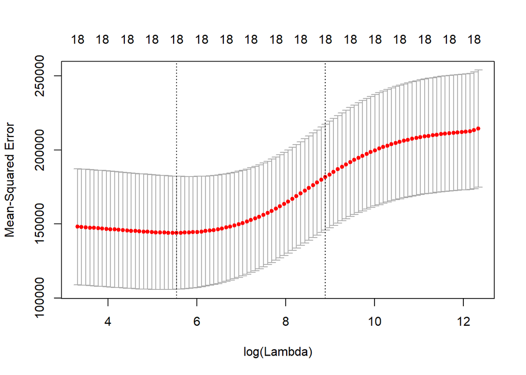

```r
set.seed(1)
cv.out = cv.glmnet(x[train,], y[train], alpha = 0)
plot(cv.out)
```

```r
bestlam = cv.out$lambda.min
bestlam
```

```
## [1] 255.0435
```

```r
ridge.pred = predict(ridge.mod, s = bestlam, newx = x[test,])
mean((ridge.pred - y.test)^2)
```

```
## [1] 96046.9
```

This represents a further improvement over the test MSE that we got using $\lambda = 4$. Finally, we refit our ridge regression model on the full data set, using the value of $\lambda$ chosen by cross-validation, and examine the coefficient estimates.

```r
out = glmnet(x, y, alpha = 0)
predict(out, type = 'coefficients', s = bestlam)[1:20,]
```

```
##  (Intercept)  (Intercept)         Hits        HmRun         Runs
##  17.10374672   0.00000000   0.99473300   0.39155947   1.16249574
##          RBI        Walks        Years       CAtBat        CHits
##   0.92499772   1.75941083   0.65724377   0.01136837   0.06184547
##       CHmRun        CRuns         CRBI       CWalks      LeagueN
##   0.43057438   0.12294381   0.13013453   0.03962605  24.60058036
##    DivisionW      PutOuts      Assists       Errors   NewLeagueN
## -86.21289069   0.18208758   0.04168183  -1.54423302   8.41679514
```

# 6.6.2 The Lasso

We saw that ridge regression with a wise choice of $\lambda$ can outperform least squares as well as the null model on the **Hitters** data set. We now ask whether the lasso can yield either a more accurate or a more interpretable model than ridge regression. In order to fit a lasso model, we once again use the **glmnet()** function; however, this time we use the argument **alpha = 1**. Other than that change, we proceed just as we did in fitting a ridge model.

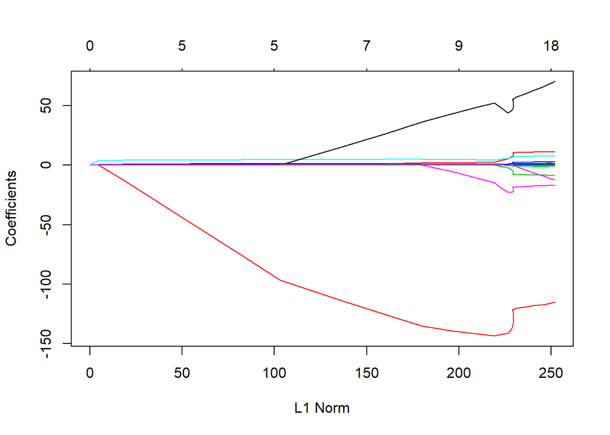

```r
lasso.mod = glmnet(x[train,], y[train], alpha = 1, lambda = grid)
plot(lasso.mod)
```

We can see from the coefficient plot that depending on the choice of tuning parameter, some of the coefficients will be exactly equal to zero. We now perform cross-validation and compute the associated test error.

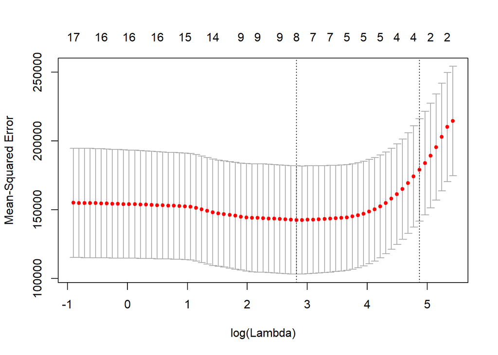

```r
set.seed(1)
cv.out = cv.glmnet(x[train,], y[train], alpha = 1)
plot(cv.out)
```

```r
bestlam = cv.out$lambda.min
lasso.pred = predict(lasso.mod, s = bestlam, newx = x[test,])
mean((lasso.pred - y.test)^2)
```

```
## [1] 100743.4
```

This is usbstantially lower than the test set MSE of the null model and of least squares, and very similar to the test MSE of ridge regression with $\lambda$ chosen by cross-validation.

```r
out = glmnet(x, y, alpha = 1, lambda = grid)
lasso.coef = predict(out, type = 'coefficients', s = bestlam)[1:20,]
lasso.coef
```

```
##  (Intercept)  (Intercept)         Hits        HmRun         Runs
##   18.5394844    0.0000000    1.8735390    0.0000000    0.0000000
##          RBI        Walks        Years       CAtBat        CHits
##    0.0000000    2.2178444    0.0000000    0.0000000    0.0000000
##       CHmRun        CRuns         CRBI       CWalks      LeagueN
##    0.0000000    0.2071252    0.4130132    0.0000000    3.2666677
##    DivisionW      PutOuts      Assists       Errors   NewLeagueN
## -103.4845458    0.2204284    0.0000000    0.0000000    0.0000000
```

```r
lasso.coef[lasso.coef != 0]
```

```
##  (Intercept)         Hits        Walks        CRuns         CRBI
##   18.5394844    1.8735390    2.2178444    0.2071252    0.4130132
##      LeagueN    DivisionW      PutOuts
##    3.2666677 -103.4845458    0.2204284
```